# LBB3_Yvonne

Yvonne Lam

9/12/2019

## Assignment for Week 3 DV

**Task: Creating a publication-grade plot**

Applying what you’ve learned, create a plot (or multiple plots) that is polished with the appropriate annotations, aesthetics and some simple commentary. Submit your LBB in knitted HTML as well as the Rmarkdown document. If you used your own dataset, please also attach the dataset.

Bonus (Optional): Creating an interactive leaflet map Applying what you’ve learned, create a leaflet interactive map. Use a map markers with popups to represent business locations. For an added challenge, use different icons or logos to replace the markers.

## Code

HDBresaleall.csv dataset will be used for this assignment.

```r
HDB <- read.csv("HDBresaleall.csv")
str(HDB)
unique(HDB$year)
```

```r
library(ggplot2)
library(dplyr)
```

First, let’s find out which HDB flat model on average commands the highest resale price after 2014.

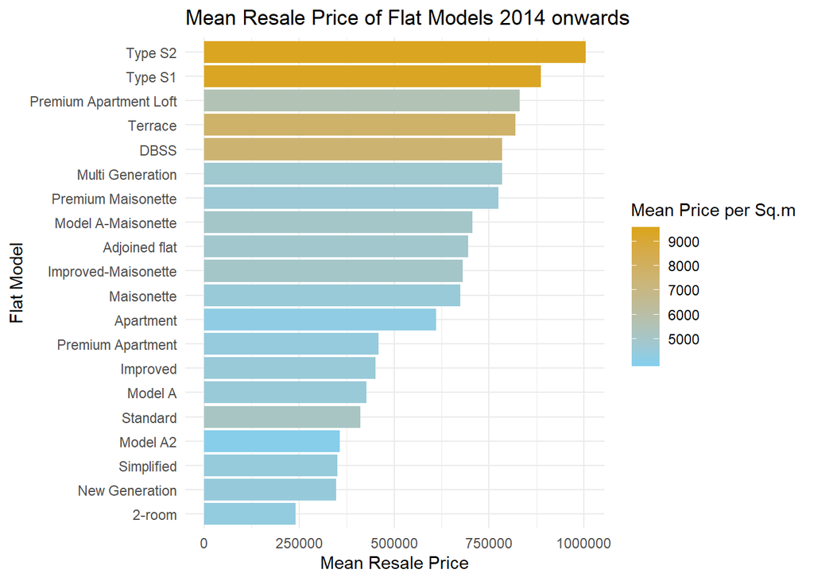

```r
Trans1419 <- HDB

#flat models with spelling errors should be re-categorised
Trans1419 <- Trans1419 %>%
  mutate(Flat_Model = replace(flat_model, flat_model == "Premium Apartment.", "Premium Apartment"))

Trans1419$Flat_Model <- droplevels(Trans1419$Flat_Model)

#calculate mean resale price and price per sq.m by grouping flat models
Trans1419 <- Trans1419 %>%
  filter(year >= 2014) %>%
  group_by(Flat_Model) %>%
  summarize(mean_resale = mean(resale_price),
            mean_psm = mean(resale_price/floor_area_sqm))


ggplot(Trans1419, aes(x=reorder(Flat_Model,mean_resale), y=mean_resale))+
  geom_col(aes(fill=mean_psm))+
  scale_fill_gradient(low="skyblue", high="goldenrod")+
  coord_flip()+
  labs(title="Mean Resale Price of Flat Models 2014 onwards", x= "Flat Model", y="Mean Resale Price", fill="Mean Price per Sq.m")+
  theme_minimal()
```

It seems like Type S2 and Type S1 flat models on average command the highest resale prices after 2014. Also, the mean price per square meter for both flat models are on the high end of the spectrum at SGD9000 and above.

Next, let’s find out if this two mean resale prices are affected by outliers.

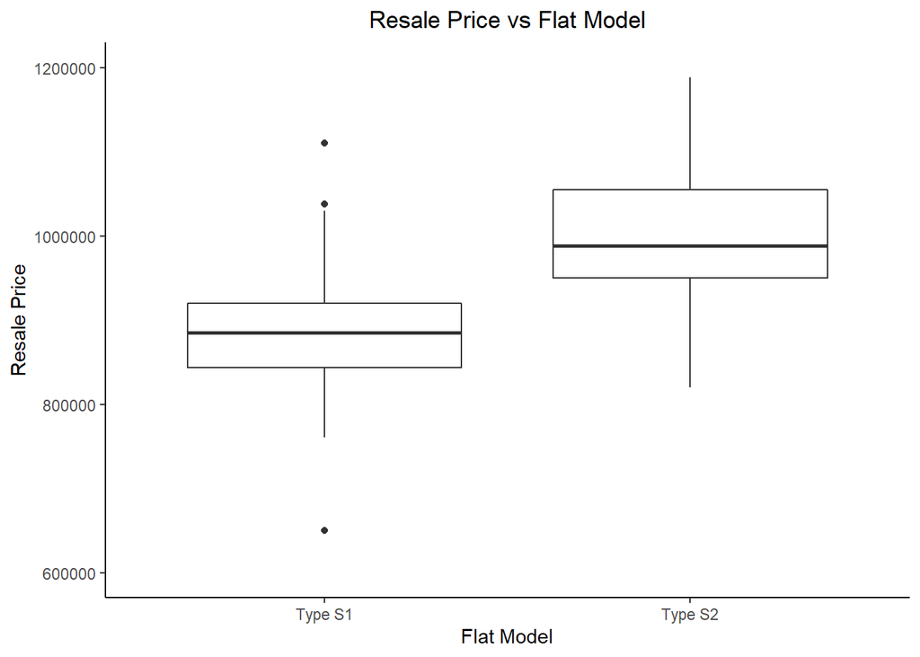

```r
flatmodelS1S2 <- HDB[HDB$flat_model == "Type S1"|HDB$flat_model == "Type S2",]

ggplot(flatmodelS1S2, aes(x= flat_model, y= resale_price))+
  geom_boxplot()+
  labs(title="Resale Price vs Flat Model", x="Flat Model", y="Resale Price")+
  theme_classic()+
  coord_cartesian(ylim=c(600000,1200000))+
  theme(plot.title= element_text(hjust=0.5))
```

```r
flatmodelS1S2$flat_model <- droplevels(flatmodelS1S2$flat_model)
table(flatmodelS1S2$flat_model)
```

```
##
## Type S1 Type S2
##     239     113
```

The boxplot above shows that Type S1 has 3 outliers and Type S2 has no obvious outliers. A further check on transaction numbers suggest that 3 out of 239 transactions for S1 flat models does not significantly affect the mean resale price by much, due to the small number of outliers. Therefore, it seems the Mean Resale Price of Type S1 and Type S2 flat models are not significantly affected by the outliers.

Lastly, let’s find out the changes in resale prices over 29 years (1990-2019) for all flat types.

```r
#calculate mean resale price by grouping factors: year and flat_type
years <- HDB %>%
  group_by(year, flat_type) %>%
  summarize(mean_resale = mean(resale_price))

unique(years$flat_type)
```

```
## [1] 1 ROOM           2 ROOM           3 ROOM           4 ROOM
## [5] 5 ROOM           EXECUTIVE        MULTI GENERATION MULTI-GENERATION
## 8 Levels: 1 ROOM 2 ROOM 3 ROOM 4 ROOM 5 ROOM ... MULTI GENERATION
```

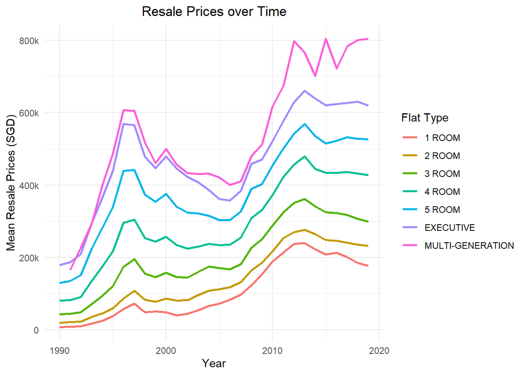

```r
#flat models with spelling errors should be re-categorised
years <- years %>%
  mutate(Flat_Type = replace(flat_type, flat_type == "MULTI GENERATION", "MULTI-GENERATION"))
years$Flat_Type <- droplevels(years$Flat_Type)

ggplot(years, aes(x= year, y= mean_resale))+
  geom_line(aes(colour=Flat_Type),size=1)+
  labs(title="Resale Prices over Time", x= "Year", y="Mean Resale Prices (SGD)", colour= "Flat Type")+
  scale_y_continuous(breaks=c(0,200000,400000,600000,800000),labels=c("0","200k","400k","600k","800k"))+
  theme_minimal()+
  theme(plot.title = element_text(hjust=0.5))
```

Bonus: Creating an interactive leaflet map

```r
library(leaflet)
#import cart icon and customizing it
icons <- awesomeIcons(
  icon = 'shopping-cart',
  iconColor = 'white',
  library = 'glyphicon',
  markerColor = 'darkblue')

leaflet() %>%
  addProviderTiles("Wikimedia") %>%
  setView(lng= 103.868409,
          lat= 1.332297,
          zoom= 20) %>%
  addAwesomeMarkers(lng=103.866945,
             lat=1.332597,
             popup="FairPrice Potong Pasir Ave 2", icon= icons) %>%
  addAwesomeMarkers(lng=103.868409,
             lat=1.332297,
             popup="Ang Mo Supermarket", icon= icons) %>%
  addAwesomeMarkers(lng=103.868483,
             lat=1.331852,
             popup="FairPrice Poiz Centre", icon= icons)
```

[interactive chart not shown]

These are supermarkets in my neighbourhood.